# The Increasing Intensity of Strong Atlantic Hurricanes

Validating Elsner et al. (2008)

James B. Elsner

26 November 2019

Science gets validated through predictions. Using satellite derived wind speed estimates from tropical cyclones Elsner, Kossin, and Jagger (2008) showed that the strongest hurricanes were getting stronger through the period 1981-2006. In particular, they found that 15% (85th quantile) of all named storms across the North Atlantic had wind speeds exceeding 48.9 m/s (Table 1 in Elsner, Kossin, and Jagger (2008) ) with an upward trend of .63 m/s/yr in this quantile wind speed. They related this increase to a corresponding rise in ocean temperatures consistent with theory (K. A. Emanuel 1988). The oceans have continued to warm since that paper was published so we would predict that the upward trend in the intensity of the strongest hurricanes has continued.

To check this, consider all North Atlantic named storms (tropical storms and hurricanes) over the 13-year period 2007–2019 [data taken from Wikipedia]. `NS` and `MH` are the annual number of named storms and major hurricanes respectively.

```r
Year <- c(2007, 2007, 2008, 2008, 2008, 2008, 2008, 2009, 2009, 2010, 2010, 2010, 2010, 2010,
          2011, 2011, 2011, 2011, 2012, 2012, 2014, 2014, 2015, 2015, 2016, 2016, 2016, 2016,
          2017, 2017, 2017, 2017, 2017, 2017, 2018, 2018, 2019, 2019, 2019)
Name <- c("Dean", "Felix", "Bertha", "Gustav", "Ike", "Omar", "Paloma", "Bill", "Fred",
          "Danielle", "Earl", "Igor", "Julia", "Karl", "Irene", "Katia", "Ophelia", "Rina",
          "Michael", "Sandy", "Edouard", "Gonzalo", "Danny", "Joaquin", "Gaston", "Matthew",
          "Nicole", "Otto", "Harvey", "Irma", "Jose", "Lee", "Maria", "Ophelia", "Florence",
          "Michael", "Dorian", "Humburto", "Lorenzo")
MPH <- c(175, 175, 125, 150, 145, 130, 140, 130, 120, 130, 145, 155, 140, 125, 120, 140, 140,
         115, 115, 115, 120, 145, 125, 155, 120, 165, 140, 115, 130, 180, 155, 115, 175, 115,
         150, 160, 185, 125, 160)
LMI.df <- data.frame(Year, Name, MPH, MPS = MPH * .44704)

NS <- c(15, 16, 9, 19, 19, 19, 14, 8, 11, 15, 17, 15, 18)
MH <- c(2, 5, 2, 5, 4, 2, 0, 2, 2, 4, 6, 2, 3)
Year <- 2007:2019

Counts.df <- data.frame(Year, NS, MH)
# sum(MH)/sum(NS) * 100
```

We note that 20% of them had wind speeds exceeding 48.9 m/s. An increase of 5 percentage points over the earlier period examined in Elsner, Kossin, and Jagger (2008).

```r
suppressPackageStartupMessages(library(dplyr))
LMI.df %>%
  arrange(desc(MPS))
```

```
##    Year     Name MPH     MPS
## 1  2019   Dorian 185 82.7024
## 2  2017     Irma 180 80.4672
## 3  2007     Dean 175 78.2320
## 4  2007    Felix 175 78.2320
## 5  2017    Maria 175 78.2320
## 6  2016  Matthew 165 73.7616
## 7  2018  Michael 160 71.5264
## 8  2019  Lorenzo 160 71.5264
## 9  2010     Igor 155 69.2912
## 10 2015  Joaquin 155 69.2912
## 11 2017     Jose 155 69.2912
## 12 2008   Gustav 150 67.0560
## 13 2018 Florence 150 67.0560
## 14 2008      Ike 145 64.8208
```

[output cut: 25 more lines]

Plot as an ordered bar plot.

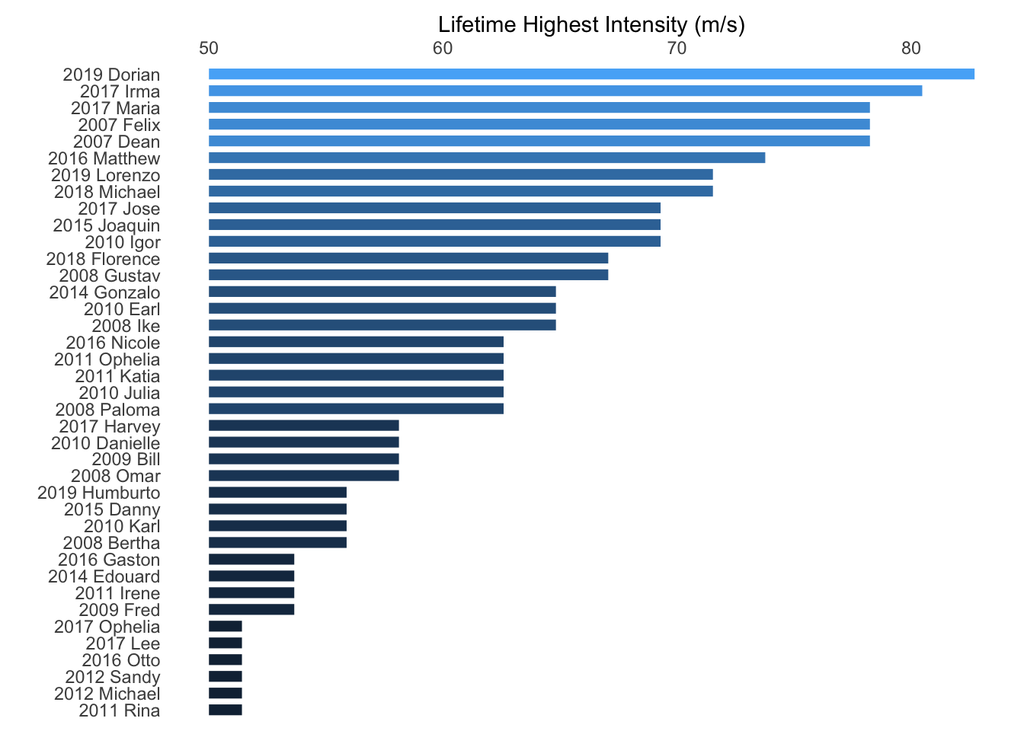

```r
LMI.df <- LMI.df %>%
  mutate(NAME = paste(Year, Name))

suppressPackageStartupMessages(library(ggplot2))
suppressPackageStartupMessages(library(forcats))

ggplot(data = LMI.df) +
  geom_segment(aes(x = reorder(NAME, MPS), y = 50,
                   xend = reorder(NAME, MPS), yend = MPS,
                   color = MPS), size = 2.5) +
  coord_flip() +
  scale_y_continuous(position = 'right') +
  xlab("") + ylab("Lifetime Highest Intensity (m/s)") +
  theme_minimal() +
  theme(panel.grid.major = element_blank(),
        panel.grid.minor = element_blank(),
        legend.position = "none")
```

```r
percentile <- (cumsum(table(LMI.df$MPS)) + (sum(NS) - sum(MH)))/sum(NS)
percentile.df <- as.data.frame(percentile)
percentile.df$MPS <- as.numeric(rownames(percentile.df))

p85ws <- round(approx(x = percentile.df$percentile, y = percentile.df$MPS, xout = .85)$y, 1)
```

Further we note that the 85th quantile wind speed has increased from 48.9 m/s to 53.5 m/s which is an increase of 4.6 m/s and which matches an extrapolation that takes the trend of .63 m/s/yr from Table 1 in Elsner, Kossin, and Jagger (2008) and multiplies it by 7 (mid point number of years in a 13-year period). [48.9 + .63 * 7 = 53.3 m/s].

```r
p95 <- round(approx(x = percentile.df$MPS, y = percentile.df$percentile, xout = 60.3)$y, 1)
p95ws <- round(approx(x = percentile.df$percentile, y = percentile.df$MPS, xout = .95)$y, 1)
```

Furthermore we note that 5% of the storms exceeded 60.3 m/s over the earlier period (Table 1, 95th quantile) but has increased to 10% over the later period. The 95th quantile wind speed has increased from 60.3 m/s to 68 m/s, which is somewhat stronger than the extrapolated trend [60.3 + .81 * 7 = 66 m/s].

It is hard to argue against this straightforward post publication analysis and the results raise the question of why Elsner, Kossin, and Jagger (2008) was largely ignored or discounted when writing “state-of-the-knowledge” reports on hurricanes and climate change (e.g., Knutson et al. (2019)).

## References

Elsner, James B., James P. Kossin, and Thomas H. Jagger. 2008. “The Increasing Intensity of the Strongest Tropical Cyclones.” *Nature* 455 (7209): 92–95. doi:10.1038/nature07234.

Emanuel, Kerry A. 1988. “The Maximum Intensity of Hurricanes.” *Journal of the Atmospheric Sciences* 45 (7): 1143–55.

Knutson, Thomas, Suzana J. Camargo, Johnny C. L. Chan, Kerry Emanuel, Chang-Hoi Ho, James Kossin, Mrutyunjay Mohapatra, et al. 2019. “Tropical Cyclones and Climate Change Assessment: Part I: Detection and Attribution.” *Bulletin of the American Meteorological Society* 100 (10). American Meteorological Society: 1987–2007. doi:10.1175/bams-d-18-0189.1.